# Impacto de olas de calor en la mortalidad infantil: el PIB como indicador de la capacidad de la adaptación

Santiago Herrero Ruipérez, Paula Manrique Álvarez, Margarita Aguzarova

2026-11-23

## 1. Introducción

El cambio climático representa uno de los mayores desafíos sanitarios del siglo XXI. Entre sus manifestaciones más evidentes se encuentra el incremento en la frecuencia, intensidad y duración de las olas de calor. Estos episodios de temperaturas extremas tienen un impacto directo y contrastado sobre la salud pública, lo que podría afectar a las poblaciones mas vulnerables.

Dentro de los grupos de riesgo, la población infantil, y en especial los lactantes y menores de un año, presenta una alta vulnerabilidad fisiológica frente al estrés térmico. Su termorregulación es inmadura, su gran superficie corporal en relación con su masa y la dependencia para su cuidado provocan una exposición a la deshidratación y fallos sistémicos desencadenados por las altas temperaturas.

No obstante, el impacto de las olas de calor no es igual para todas las poblaciones ni para todas las comunidades autónomas, el efecto de las olas de calor es influido por los factores socioeconómicos y ambientales. En España existen variedades climáticas significativas entre comunidades autónomas que se enlazan a desigualdades socioeconómicas.

El producto interior bruto per cápita y el nivel de desarrollo económico por comunidad autónoma actúan como variables medidoras. Las regiones con un mayor PIB suelen tener acceso a mejores infraestructuras sanitarias, viviendas mejor acondicionadas y una mayor capacidad de respuesta frente a emergencias climáticas, lo que podría mitigar parte del impacto de las altas temperaturas en la salud infantil.

El informe tendrá como objetivo analizar si existe algún tipo de relación entre la intensidad y frecuencias de olas de calor, la mortalidad infantil y el PIB por comunidad autónoma en España. Con este informe buscaremos identificar patrones y cuantificar el impacto del PIB como factor protector.

En España, la AEMET considera que hay una ola de calor cuando se registran temperaturas máximas diarias superiores al percentil 95 de su serie histórica de referencia (meses de julio y agosto) en al menos el 10% de las estaciones metereológicas, durante un periodo mínimo de tres días consecutivos, AEMET considera que la referencia de datos son los registrados entre los años 1971 y 2000.

## 2. Objetivo general

El objetivo general de este seminario es estudiar si existe alguna relación entre las olas de calor y la mortalidad infantil en las comunidades autónomas de España durante el periodo 2001-2025, teniendo en cuenta el producto interior bruto (PIB) como posible factor que pueda afectar esa relación.

## 3. Objetivos específicos

1. Estudio de la relación entre el número de olas de calor y la mortalidad infantil por comunidades autónomas en el periodo 2001-2025.
2. Estudio de la relación entre la duración e intensidad de las olas de calor y la mortalidad infantil.
3. Comparación de la mortalidad infantil durante los años con olas de calor entre comunidades autónomas con distinto PIB.

## 4. Metodología

### 4.1 Datos de las olas de calor

Los registros de olas de calor se identificaron filtrando los datos de las estaciones meteorológicas de la AEMET (Agencia Estatal de Meteorología 2026), descargados a través de su API oficial y guardándolos en un environment, y aplicando los criterios metodológicos establecidos por dicho organismo.

Tras una limpieza de datos general limpiando los datos de precipitaciones y asegurando el tipo DATE, se calcula el percentil 95 según la guía de la AEMET para poder identificar las olas de calor posteriormente.

```r
datos_trabajo2 <- datos_trabajar %>%
  mutate(
    fecha = as.Date(fecha),
    prec = as.numeric(stringr::str_replace(prec, ",", "."))
  )
```

Identificamos las rachas de calor iguales o mayores a tres días

```r
#tabla diaria del % de estaciones que superan el umbral de calor
diario <- datos_trabajo2 %>%
  inner_join(p95, by = "indicativo") %>%
  filter(!is.na(tmax), !is.na(p95)) %>%
  group_by(fecha) %>%
  summarise(
    n_est = n(),
    pct_sup = mean(tmax > p95) * 100,
    .groups = "drop"
  ) %>%
  arrange(fecha) %>%
  mutate(dia_calido = pct_sup >= 10)
```

```r
olas <- diario %>%
  mutate(
    nueva = is.na(lag(dia_calido)) |
      dia_calido != lag(dia_calido) |
      as.numeric(fecha - lag(fecha)) != 1,
    racha_id = cumsum(nueva)
  ) %>%
  filter(dia_calido) %>%
  group_by(racha_id) %>%
  summarise(
    inicio = as.Date(min(fecha)),
    fin = as.Date(max(fecha)),
    dias = n(),
    max_pct = max(pct_sup),
    .groups = "drop"
  ) %>%
  filter(dias >= 3) %>%
  mutate(racha = row_number())
```

Finalmente tras expandir cada ola de calor oficial mediante id_ola para que no coincida con la racha de AEMET (viento), cruzamos los datos de las estaciones diarios para calcular las métricas por provicia y año.

```r
#expando cada ola oficial a sus días concretos usando id_ola para que no coincida con racha de aemet (viento)
dias_ola_oficial <- do.call(rbind, lapply(seq_len(nrow(olas)), function(i) {
  data.frame(
    fecha = seq(as.Date(olas$inicio[i]), as.Date(olas$fin[i]), by = "day"),
    id_ola = olas$racha[i]
  )
}))
```

```r
olas_por_provincia <- datos_trabajo2 %>%
  mutate(fecha = as.Date(fecha)) %>%
  inner_join(dias_ola_oficial, by = "fecha") %>%
  inner_join(p95, by = "indicativo") %>%
  filter(tmax > p95) %>%
  mutate(
    anio = lubridate::year(fecha),
    exceso_termico = tmax - p95
  ) %>%
  ungroup() %>%
  group_by(provincia, anio, id_ola) %>%
  summarise(
    dias_ola = dplyr::n_distinct(fecha),
    intensidad_media = mean(exceso_termico, na.rm = TRUE),
    .groups = "drop"
  ) %>%
  group_by(provincia, anio) %>%
  summarise(
    frecuencia_anual = dplyr::n_distinct(id_ola),
    duracion_media_ola = mean(dias_ola, na.rm = TRUE),
    intensidad_acumulada = sum(intensidad_media, na.rm = TRUE),
    .groups = "drop"
  )
```

### 4.2 Datos de mortalidad infantil

Los datos de mortalidad se sacaron de la *Estadística de defunciones según la causa de muerte* del Instituto Nacional de Estadística (Instituto Nacional de Estadística 2026a), descargados en formato `.json`.

```r
peninsula <- tidyjson::read_json("INPUT/DATA/peninsula.json")
```

Se seleccionan las muertes por todaas las causas y ambos sexos en cada comunidad autónoma, sin incluir el total nacional ni el extranjero. Los datos se filtran de 2001 a 2025 para poder compararlos con los datos de olas de calor.

```r
library(tidyjson)
datos <- peninsula %>%
  gather_array("serie") %>%
  spread_all() %>%
  select(document.id, Nombre) %>%
  filter(str_detect(Nombre, "Menos de 1 año|Menores de 1 año")) %>% # se filtran las edades para que sólo sean bebés menores de 1 año
  enter_object(Data) %>%
  gather_array() %>%
  spread_all() %>%
  filter(Anyo >= 2001, Anyo <= 2025) %>% # se filtran los años de 2001 a 2025
  select(Nombre, Anyo, Valor, T3_TipoDato) %>%
  as_tibble()
```

```r
# se separa el nombre de la serie en columnas
datos <- datos %>%
  separate_wider_delim(Nombre, delim = ". ",
                       names = c("causa", "sexo", "edad", "comunidad", "tipo"),
                       too_many = "drop")
```

```r
# se toman todas las causas y ambos sexos, por comunidad
por_comunidad <- datos %>%
  filter(str_detect(causa, "Todas las causas"), sexo == "Total",
         comunidad != "Total Nacional", comunidad != "Extranjero") %>%
  rename(grupo = comunidad)
```

```r
# se toma el total nacional y ambos sexos, por causa
por_causa <- datos %>%
  filter(!str_detect(causa, "Todas las causas"), sexo == "Total",
         comunidad != "Total Nacional", comunidad != "Extranjero") %>%
  group_by(causa, Anyo) %>%
  summarise(Valor = sum(Valor), .groups = "drop") %>%
  rename(grupo = causa) %>%
  mutate(grupo = str_wrap(grupo, width = 25)) # para los nombres demasiado largos
```

### 4.3 Datos del PIB

Los datos del PIB se sacaron de la *Contabilidad Regional de España* del Instituto Nacional de Estadística (Instituto Nacional de Estadística 2026b), concretamente de la tabla del PIB a precios de mercado, a precios corrientes, por comunidades y ciudades autónomas y provincias, descargada en formato `.json`.

```r
library(jsonlite)
pib_raw <- fromJSON("INPUT/DATA/pib.json")
```

```r
pib_tabla <- pib_raw %>%
  as_tibble() %>%
  mutate(
    nivel      = map_chr(MetaData, ~ .x$T3_Variable[1]),  # CCAA / Provincias / NUTS1 / Total
    territorio = map_chr(MetaData, ~ .x$Nombre[1]),       # nombre original del INE
    tipo       = map_chr(MetaData, ~ .x$Nombre[2])        # Dato base / Tasa de Variación Interanual / Estructura Porcentual
  ) %>%
  select(COD, nivel, territorio, tipo, T3_Unidad, T3_Escala, Data) %>%
  unnest(Data) %>%
  mutate(Valor = as.numeric(Valor))
```

Se conservaron solo las comunidades y ciudades autónomas,cubriendo los años del 2000 a 2025.

```r
pib_ccaa <- pib_tabla %>%
  filter(nivel == "Comunidades y Ciudades Autónomas") %>%
  mutate(grupo = str_remove(territorio,
                            ", Comunidad de|, Región de|, Principado de|, Comunidad Foral de"))
```

Después se separaron dos series: el PIB en euros y la tasa de variación interanual.

```r
pib_euros <- pib_ccaa %>%
  filter(tipo == "Dato base") %>%
  mutate(Valor = Valor / 1e6)

pib_tasa <- pib_ccaa %>%
  filter(tipo == "Tasa de Variación Interanual")
```

Para poder trabajar con los datos de mortalidad, se simplificaron los nombres de las comunidades para que coincidan con los de los datos de mortalidad, pues los primeros estan por provincias y los del producto interior bruto son comunidaddes autónomas.

```r
ola_ccaa <- olas_por_provincia %>%
  mutate(provincia = toupper(provincia)) %>%
  mutate(grupo = case_when(
    provincia %in% c("ALMERIA", "ALMERÍA", "CADIZ", "CÁDIZ", "CORDOBA", "CÓRDOBA", "GRANADA",
                     "HUELVA", "JAEN", "JAÉN", "MALAGA", "MÁLAGA", "SEVILLA")        ~ "Andalucía",
    provincia %in% c("HUESCA", "TERUEL", "ZARAGOZA")                                ~ "Aragón",
    provincia %in% c("ASTURIAS")                                                    ~ "Asturias",
    provincia %in% c("BALEARES", "ILLES BALEARS", "ISLAS BALEARES")                 ~ "Balears, Illes",
    provincia %in% c("LAS PALMAS", "PALMAS, LAS", "SANTA CRUZ DE TENERIFE",
                     "STA. CRUZ DE TENERIFE")                                       ~ "Canarias",
    provincia %in% c("CANTABRIA")                                                   ~ "Cantabria",
    provincia %in% c("AVILA", "ÁVILA", "BURGOS", "LEON", "LEÓN", "PALENCIA", "SALAMANCA",
                     "SEGOVIA", "SORIA", "VALLADOLID", "ZAMORA")                    ~ "Castilla y León",
    provincia %in% c("ALBACETE", "CIUDAD REAL", "CUENCA", "GUADALAJARA", "TOLEDO")  ~ "Castilla - La Mancha",
    provincia %in% c("BARCELONA", "GIRONA", "GERONA", "LLEIDA", "LERIDA", "TARRAGONA") ~ "Cataluña",
    provincia %in% c("ALICANTE", "CASTELLON", "CASTELLÓN", "VALENCIA")              ~ "Comunitat Valenciana",
    provincia %in% c("BADAJOZ", "CACERES", "CÁCERES")                               ~ "Extremadura",
    provincia %in% c("CORUÑA, A", "A CORUÑA", "LA CORUÑA", "LUGO", "OURENSE",
                     "PONTEVEDRA")                                                  ~ "Galicia",
    provincia %in% c("MADRID")                                                      ~ "Madrid",
    provincia %in% c("MURCIA")                                                      ~ "Murcia",
    provincia %in% c("NAVARRA")                                                     ~ "Navarra",
    provincia %in% c("ALAVA", "ÁLAVA", "ARABA/ALAVA", "GIPUZKOA", "GUIPUZCOA",
                     "BIZKAIA", "VIZCAYA")                                          ~ "País Vasco",
    provincia %in% c("RIOJA, LA", "LA RIOJA")                                       ~ "Rioja, La",
    provincia %in% c("CEUTA")                                                       ~ "Ceuta",
    provincia %in% c("MELILLA")                                                     ~ "Melilla",
    .default = NA
  ))
```

### 4.4 Unión de los datos

Los datos de las estaciones de la AEMET están por provincia. Por lo tanto, se agruparon por comunidad. Después se unieron las tablas de olas de calor, mortalidad y PIB por comunidad autónoma y año.

Como las comunidades más grandes tienen más nacimientos, y por lo tanto más muertes, no se compararon directamente los números de muertes. Se calculó el índice de mortalidad para cada comunidad, donde 100 indica un año normal. En la pregunta 1 el año normal se calculó con la tendencia de cada comunidad, ya que la mortalidad infantil baja con los años.

Para la pregunta 3, las comunidades se clasificaron en PIB alto o PIB bajo según si su PIB medio estaba por encima o por debajo del umbral (la media de todas las comunidades).

## 5. Resultados / Discusión

### 5.1 Pregunta 1: ¿Cómo varía la mortalidad infantil según el número de olas de calor en cada comunidad autónoma?

```
## Ignoring unknown labels:
## • colour : "Comunidad autónoma"
```

[interactive chart not shown]

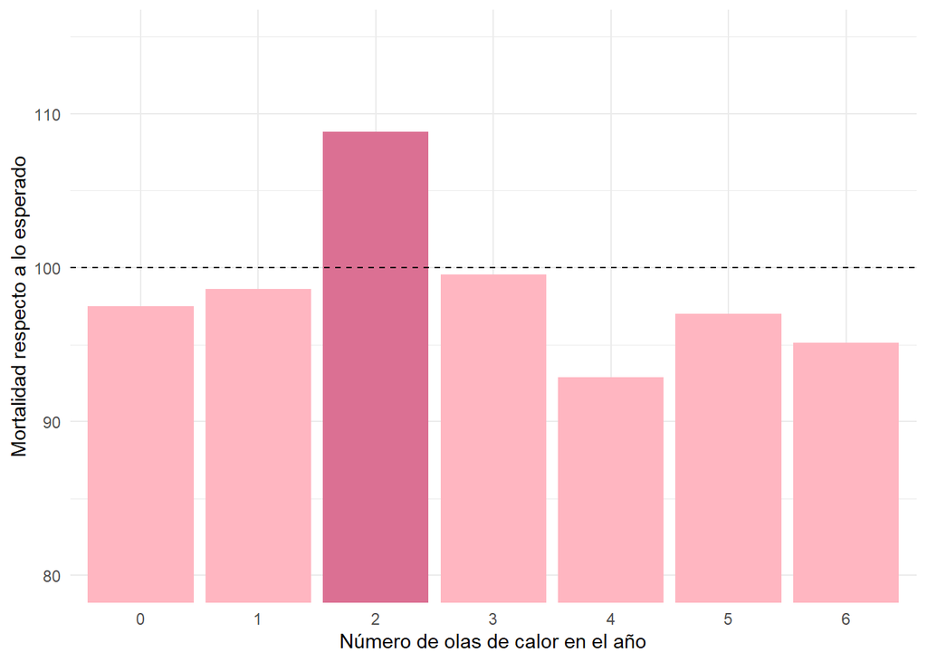

La mortalidad infantil se mantiene cerca del umbral (100) sea cual sea el número de olas de calor. Sólo los años con 2 olas lo superan.Por lo tanto, no se observa una relación clara.

### 5.2 Pregunta 2:¿Qué dimensión de las olas de calor ejerce un mayor impacto sobre la mortalidad infantil?

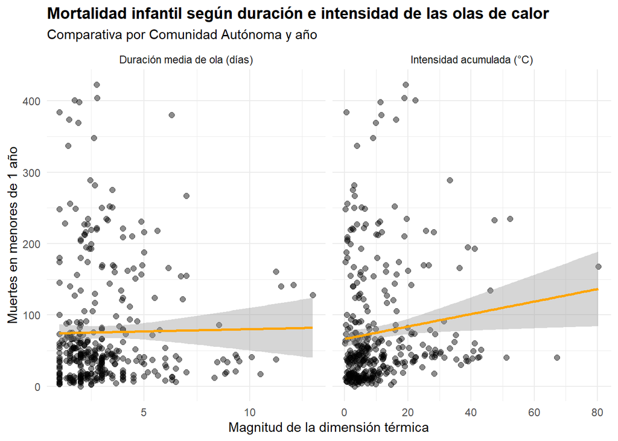

Se puede observar que la recta de la media de las olas queda prácticamente plana, mientras que la intensidad acumulada presenta una ligera tendencia positiva, aunque la dispersión es elevada y el intervalo de confianza es amplio. Por lo tanto, no se puede demostrar una relación clara.

| nivel_pib | con_ola | indice_medio | n_anios_ccaa |
| --- | --- | --- | --- |
| PIB bajo | Con ola | 98.37238 | 261 |
| PIB bajo | Sin ola | 105.66412 | 75 |
| PIB alto | Con ola | 98.96725 | 106 |
| PIB alto | Sin ola | 107.81942 | 14 |

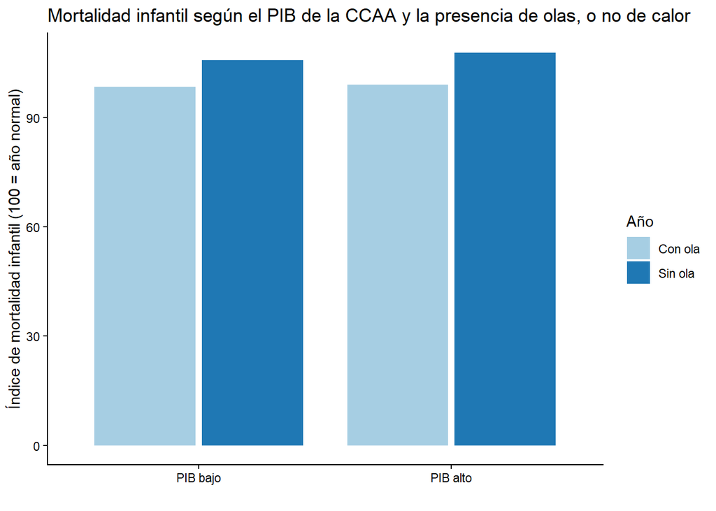

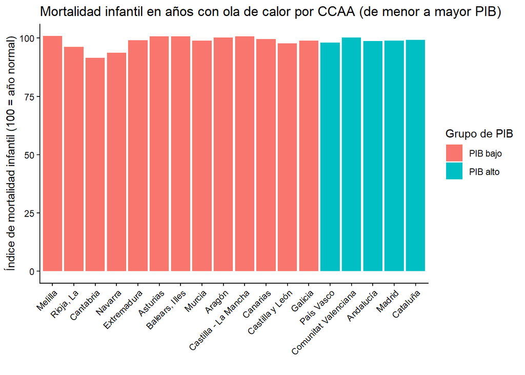

Se puede observar que el índice de mortalidad infantil, en los años con ola de calor, queda casi igual tanto en las comunidades del PIB bajo, como en las del PIB alto, quedando cerca de 100. Los años sin ola presentan valores más altos, lo que se explica por la bajada de la mortalidad infantil con los años y no por un efecto protector de calor.

## 6. Conclusión

En este seminario se ha analizado la relación entre las olas de calor y la mortalidad infantil en España entre 2001 y 2025, combinando datos de temperatura de la Agencia Estatal de Meteorología, datos de defunciones de menores de un año del Instituto Nacional de Estadística y datos de PIB regional del mismo organismo. A partir de ellos se han planteado tres preguntas: cómo varía la mortalidad infantil según el número de olas de calor, qué dimensión de las olas (duración o intensidad) se asocia más con ella y si esta relación difiere entre comunidades autónomas con distinto nivel de PIB.

Respecto a la primera pregunta, la mortalidad infantil respecto a lo esperado no aumenta con el número de olas de calor. El indice se mantiene constante en 100 o por debajo con 0, 1, 3, 4, 5 y 6 olas, y tan solo aquellos años con dos olas destacan por encima de lo esperado. Este ultimo valor se trata de un valor aislado, pues no va seguido de un aumento en los años con ters o más olas, por lol que no puede interpretarse como una relación entre la mortalidad y el calor. Además en el diagrama de cajas losd atos se solapan y la dispersión es muy grande, con valores entre 20 y 200. También hay que destacar la escasez de datos presentes con 5 y 6 olas, por lo que las medias se pueden ver afectadas por valores extremos.

En la segunda pregunta, la duración media de las olas de calor no muestra una relación clara con el número de muertes infantiles, ya que la recta de tendencia es prácticamente plana y el intervalo de confianza se ensancha hacia valores altos. La intensidad acumulada presenta una pendiente positiva más marcada, por lo que es la dimensión con una tendencia más visible. No obstante, al tratarse de datos anuales y autonómicos, la dispersión es elevada y unos pocos valores extremos influyen en la recta, por lo que esta asociación debe interpretarse como visual y no concluyente. Además, la intensidad acumulada se obtiene sumando los valores de las provincias de cada comunidad, lo que puede favorecer a las comunidades con más provincias, que a su vez tienden a registrar más muertes.

En la tercera pregunta, al comparar cada comunidad con su propia media, no se observa que el nivel de PIB modifique de forma apreciable la mortalidad infantil en los años con olas de calor: el índice medio es de 98,4 en las comunidades de PIB bajo y de 99,0 en las de PIB alto. En los años sin ola, los valores son de 105,7 y 107,8 respectivamente. Estos resultados no son los esperados, y se explican en gran parte por la limitación de los datos: al no disponer de la mortalidad por días, sino por años, no es posible aislar las muertes que ocurrieron durante cada ola de calor, y su efecto queda diluido entre las muertes del resto del año. Los años con ola presentan además menos mortalidad que los años sin ola, lo que se atribuye a la tendencia descendente de la mortalidad infantil desde 2001 y a la mayor frecuencia de olas en los años recientes, y no a un efecto protector del calor.

## 7. Enlace al repositorio

https://github.com/RitaAguz/Olas_de_calor.git

## 8. Bibliografía

Agencia Estatal de Meteorología. 2026. *Datos Climatólogos de Las Estaciones Meteorológicas de España*. https://www.aemet.es/es/datos_abiertos/AEMET_OpenData.

Instituto Nacional de Estadística. 2026a. *Estadística de Defunciones Según La Causa de Muerte*. https://www.ine.es/dyngs/INEbase/operacion.htm?c=Estadistica_C&cid=1254736176780&idp=1254735573175.

Instituto Nacional de Estadística. 2026b. *Producto Interior Bruto a Precios de Mercado (PIB): Precios Corrientes Por Comunidades y Ciudades Autónomas y Provincias. Contabilidad Regional de España, Serie 2000-2025*. https://www.ine.es/jaxiT3/Tabla.htm?t=80109.